# LDA_project

Author

a-f-katz

Published

19.12.2025

Abstract

Первый подход к анализу большого корпуса интервью. Тренируемся на маленьком

## Описание корпуса

С 2022 г. мне довелось участвовать в довольно масштабном исследовании общины горских евреев г. Пятигорска. Еврейская община г. Пятигорска представляет собой интересную картину с точки зрения миграционных процессов: с одной стороны, это молодая, активно развивающаяся община, ставшая в 1990-е и 20000-е направлением миграции для горских евреев Кавказа, с другой, Пятигорск стал промежуточным пунктом на пути более удаленных направлений миграций.

В ходе исследования мы провели ряд экспедиций в Пятигорске и окрестностях, всего было собрано порядка 300 интервью, некоторые из которых занимают более 3 часов записей. Как правило, это неструктурированные интервью, в котором собиратель хоть и задает своему собеседнику вопросы, но не настаивает на конкретной теме и следует, скорее, логике беседы, чем заранее подготовленному опроснику.

На данный момент экспедиционная часть исследования практически подошла к концу, участники экспедиций уже сделали ряд докладов и опубликовали ряд текстов по полученным материалам. Однако, как это часто бывает с масштабными проектами, материал в полном его объеме сами участники экспедиций вряд ли смогут охватить своим вниманием в ближайшие годы. Соответственно, стоит задача превратить полученный архив экспедиций в корпус (не только текстовых) материалов, в которых сможет разобраться и гипотетический исследователь, не участвовавший в экспедициях, но желающий использовать материалы в своих работах. Естественно, обработка всего массива интервью - задача не одной недели и не одного месяца. Поэтому на данном этапе я решила сделать небольшой пробный заплыв.

Для пробного тематического анализа я взяла 10 случайных интервью из материалов 2022 года (не потому, что это особенный год, а потому, что за давностью этот год наиболее полно представлен в уже расшифрованных текстах). Все интервью довольно объемные (в основном, дольше 2 часов), что позволило мне надеяться, что я смогу выделить основные темы этих документов. Разумеется, в силу использования небольшого количества текстов для пробного анализа, речь не идет о каких-то откровениях. Наоборот, зная содержание тематических опросников, на которые могли ориентироваться собиратели, и участвуя в ряде этих интервью в качестве собирателя, я расчитываю на то, что знакомство с материалом позволит мне лучше определить адекватность отображаемых результатов.

## Подготовка материалов

Имеющиеся в моем распоряжении расшифровки 10 интервью были сохранены. Подготовка текстов к анализу не представляла из себя ничего сверхъестественного[^1]:

1. из текстов были удалены специальные символы
2. все слова приведены к нижнему регистру
3. удалены лишние пробелы

   ```r
   texts_clean <- texts |>
     mutate(
       # Удаляем специальные символы, но сохраняем буквы
       text = gsub("[^[:alnum:][:space:]]", " ", text),

       # Приводим к нижнему регистру
       text = tolower(text),

       # Удаляем лишние пробелы
       text = str_squish(text)
     )
   ```

4. проведена токенизация
5. аннотирование (без синтаксического анализа) при помощи udpipe
6. лемматизация (с сохранением только существительных и прилагательных - выбор был сделан после нескольких не очень удачных попыток анализа с использованием также глаголов и имен собственных)

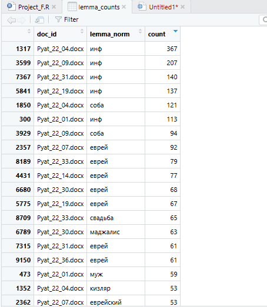

   Наиболее популярные леммы

   ```r
   rubbish_lemmas <- c(
     "соба", "бака", "ага", "щас", "тыще"
   )

   top_lemmas <- topfeatures(dfm_filtered, n = 50)

   top_lemmas_clean <- top_lemmas[!names(top_lemmas) %in% rubbish_lemmas]
   ```

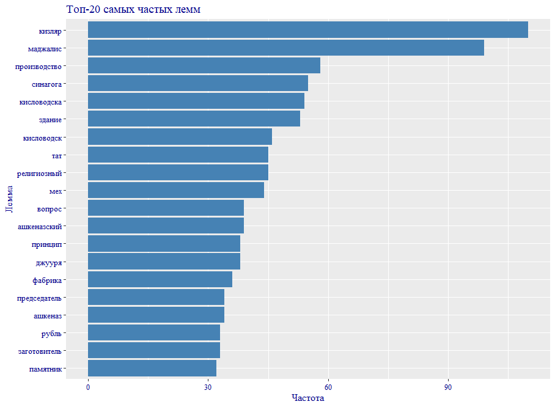

В результате получился довольно презентабильный набор лемм (правда, меня до сих пор радует мысль, что udpipe сделал из “джуури” прекрасное слово “джууря”, которое я собираюсь ввести в оборот среди коллег).

Посмотрим на не менее красивое облако слов из того же топа лемм.

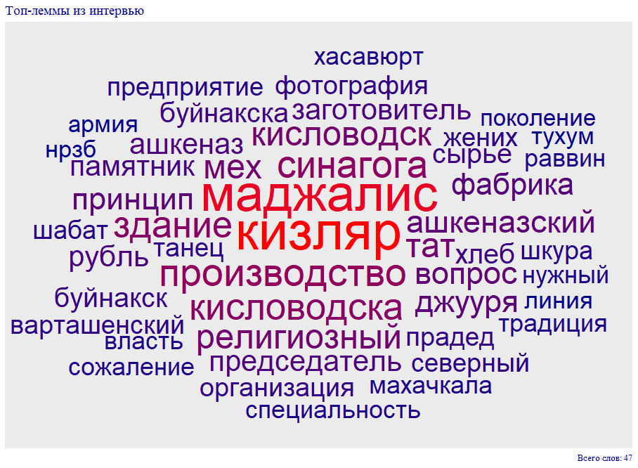

Топ лемм, которые будут использоваться для обучения модели

## Обучение модели

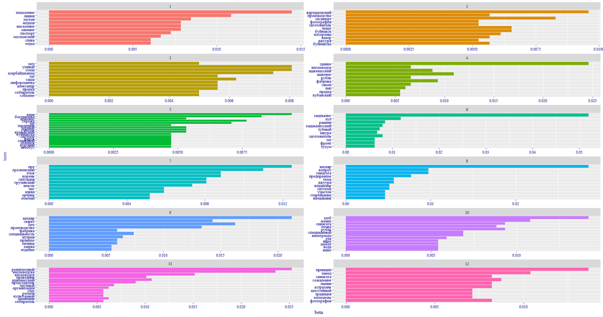

Результат поиска 12 тем

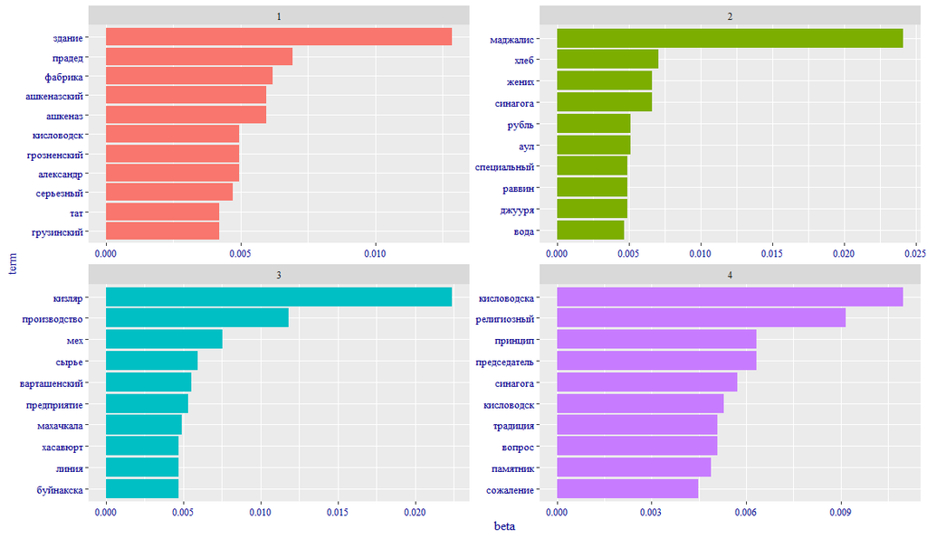

Результат обучения на 4 темы

## Результаты

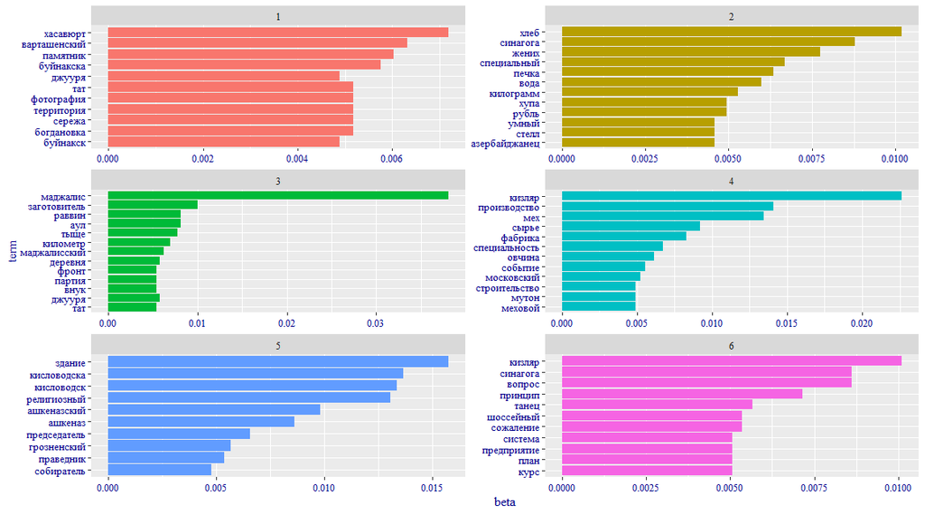

Результаты тематического моделирования

Представленный выше результат легко поддается интерпретации, если знать содержание интервью:

1. Рассказы про активиста, который занимался установкой памятника евреям, расстрелянным под Богдановкой (частый ответ на расспросы про Холокост);
2. Описание свадебных традиций;
3. Семейные истории - о родственниках и так называемой “общине исхода”;
4. Рассказ про профессии и особенности бизнеса (значительное число горских евреев в регионе Минеральных вод занимались в свое время мехозаготовками, а позже продажей шуб);

[figure not shown]

   Пятигорские меха

5. Рассказ про еврейскую общину в Кисловодске (в которой всей основной общинной деятельностью занимаются ашкеназы, точнее - 3 активные дамы-ашкеназки);

Рассказ про синагогу горских евреев в Пятигорске (первая синагога появилась на ул.Шоссейная) и про то, как все печалятся о погибшем идейном вдохновителе ее строительства.

Для пущей наглядности я подписала темы в полученном графике.

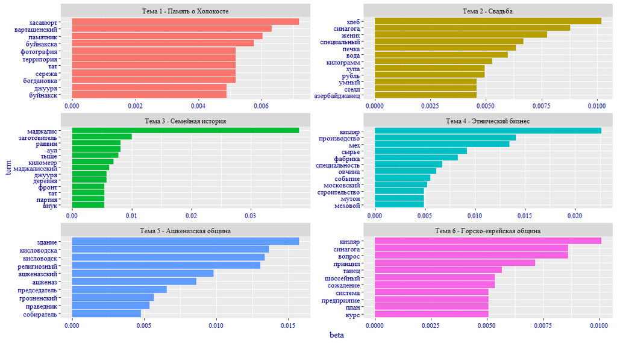

Темы

Так как интересует меня в первую очередь не красивая визуализация того, что я и так знаю из [качественного анализа интервью](https://slavsjewsculture.org/index.php/sjc/article/view/160/160) и опросников, а возможность в дальнейшем сделать обширные материалы удобными для исследователей, я решила попробовать посмотреть и на то, как темы распределены по имеющимся интервью. Для 10 интервью это, понятное дело, не играет особой практической значимости: прочитать или прослушать их, вероятно, проще, чем произвести все вышеописанное. Но я надеюст на то, что при обучении на значительно большем количестве документов результаты будут и более показательными и более полезными.

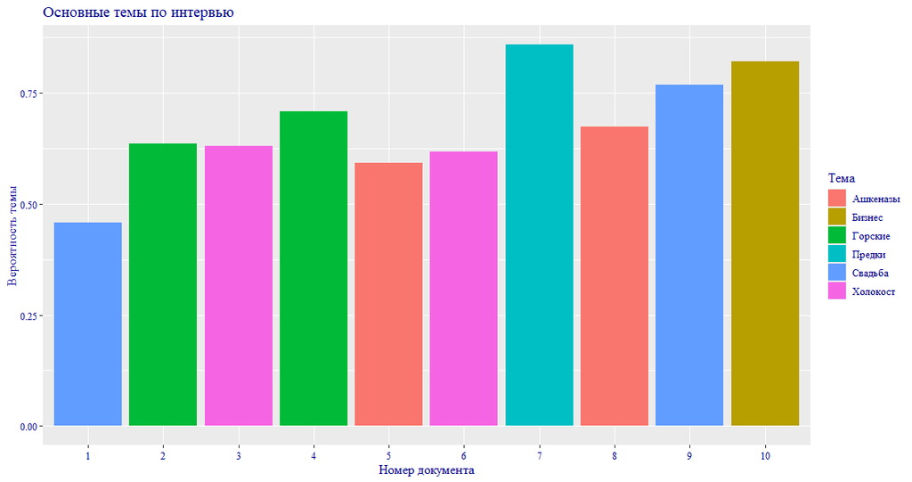

Самые популярные темы в конкретных документах

## Выводы

В целом, я довольна полученными результатами. Мне удалось получить результаты, поддающиеся интерпретации, соответствующие моим знаниям о содержании документов. Я расчитываю использовать проверенные инструменты для обработки всего имеющегося в моем распоряжении объема документов, что должно позволить исследователям, не работавшим в экспедициях, получить наглядное представление о содержании документов и сделать непростой выбор о том, с каких документов им стоит начинать работу с архивом экспедиции по интересующей их теме.

Должна извиниться за то, что в силу достаточно чувствительной личной информации, содержащейся в некоторых документах, я не имею права делиться материалами, на которых я проверяла приемы тематического анализа текста. Однако, как мы надеемся, в ближайшие пару лет данные материалы станут частью большого цифрового архива Еврейского музея и центра толерантности, и с предварительно анонимизированными текстами можно будет ознакомиться и официально работать.

## References

Classicus, Locus. 2024. “Text Analysis Course.” 2024. https://locusclassicus.github.io/text_analysis_2024/.

## Footnotes

[^1]: Методы воспроизводимых исследований подробно описаны в курсе (Classicus 2024).
[^2]: Безусловно, более опрятным было бы сделать текстовый документ с выделенными стоп-словами, однако в данном пробном забеге я позволила себе то решение, которое показалось мне более быстрым. При большом объеме данных настоятельно рекомендую сама себе не пренебрегать собственным советом